# individual2

## 2

The most ratings were done in the year 2015

The number of ratings increased from 2006 to 2015 then started to decline

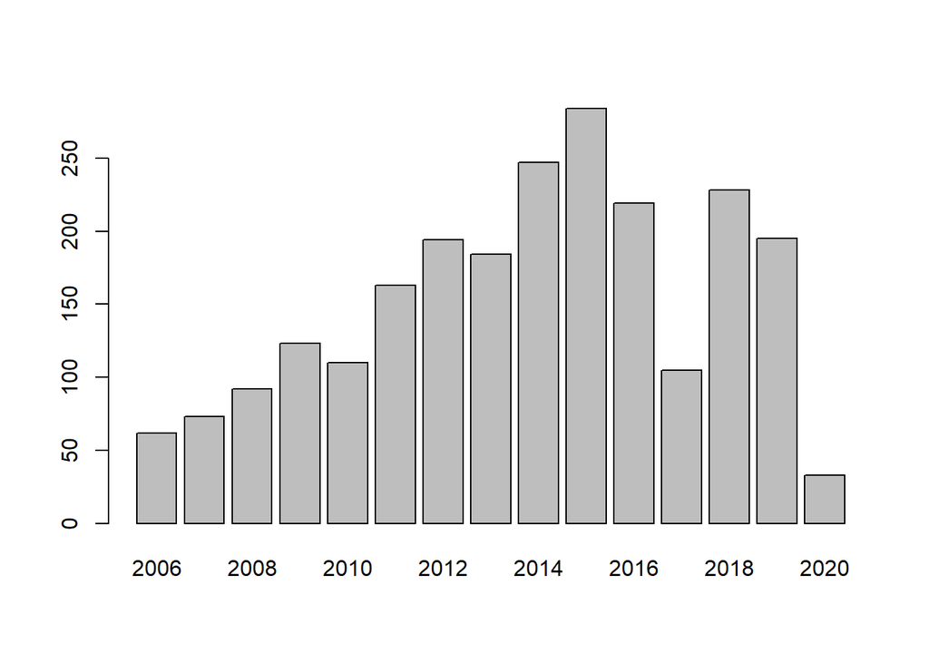

## 3

There does not seem to be any correlation between cacao percentage and the rating of the chocolate bar

We can see that almost all ratings have a chocolate that has high cocoa percentage

There is no clear distinction of any trend lines in this scatter plot

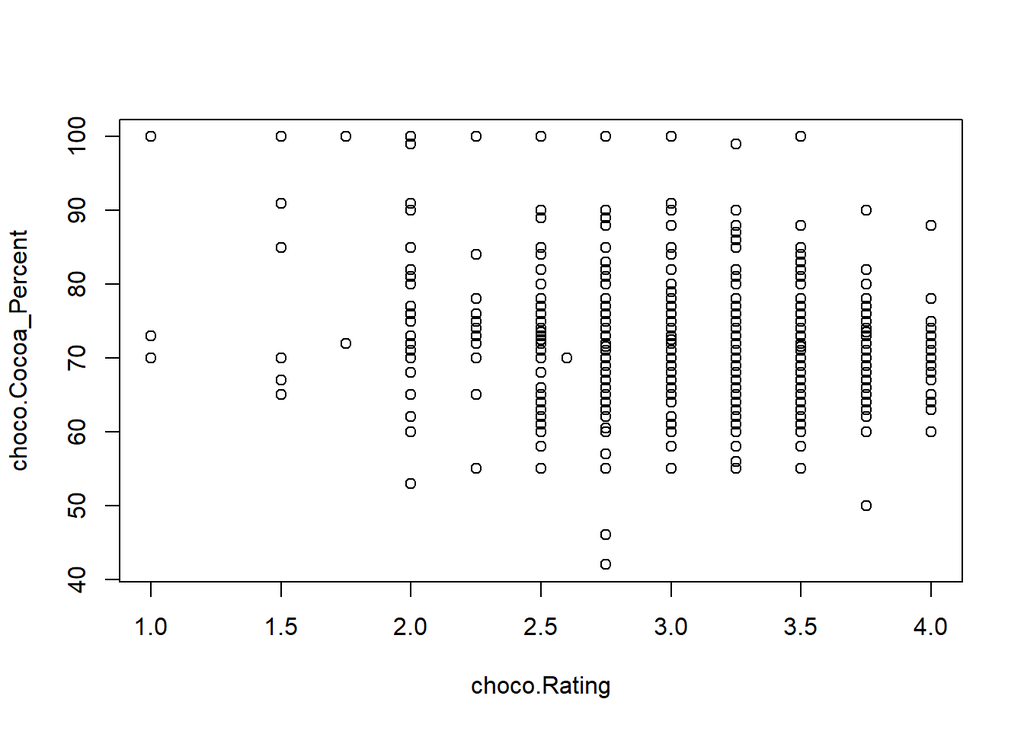

## 4

I separated the ratings into their respective categories (1 - 1.9, 2 - 2.9, 3 - 3.49, etc.), took the top rated, and took the top 5 that occurred most often

Creamy is the most common in the 4 - 5 rating

Creamy is most common in the 3.5 - 4 rating

Sandy is most common in the 3 - 3.49 rating

Sandy is most common in the 2 - 2.9 rating

We can say that top rating chocolates usually have Creamy as their first characteristic

```
##    choco.Characteristics1 choco.Rating Freq
## 11                 creamy            4   34
## 21                intense            4    4
## 2                  banana            4    3
## 10                complex            4    3
## 31                   oily            4    3
```

```
##     choco.Characteristics1 choco.Rating Freq
## 278                 creamy         3.75   39
## 423                  spicy         3.75   13
## 369                  nutty         3.75   12
## 273                  cocoa         3.75    8
## 297                 floral         3.75    8
```

```
##     choco.Characteristics1 choco.Rating Freq
## 406                  sandy         3.25   25
## 278                 creamy         3.25   19
## 328                intense         3.25   18
## 381                   oily         3.25   17
## 376                  nutty         3.25   15
```

```
##     choco.Characteristics1 choco.Rating Freq
## 770                  sandy         2.75   20
## 697                  fatty         2.75   19
## 708                 gritty         2.75   14
## 796                  sweet         2.75   13
## 686                 creamy         2.75   12
```

```
##    choco.Characteristics1 choco.Rating Freq
## 36                  cocoa         1.75    1
## 40                 pastey         1.75    1
## 45             very nutty         1.75    1
## 31                 acidic         1.75    0
## 32                 bitter         1.75    0
```

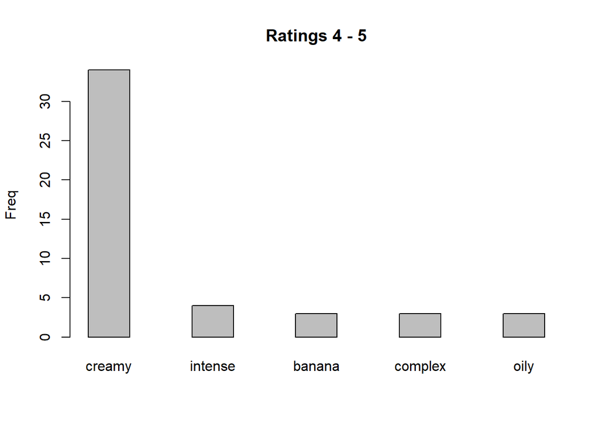

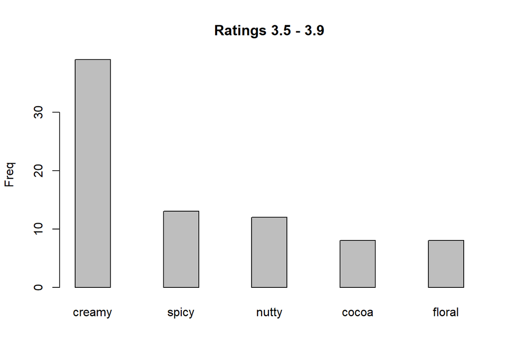

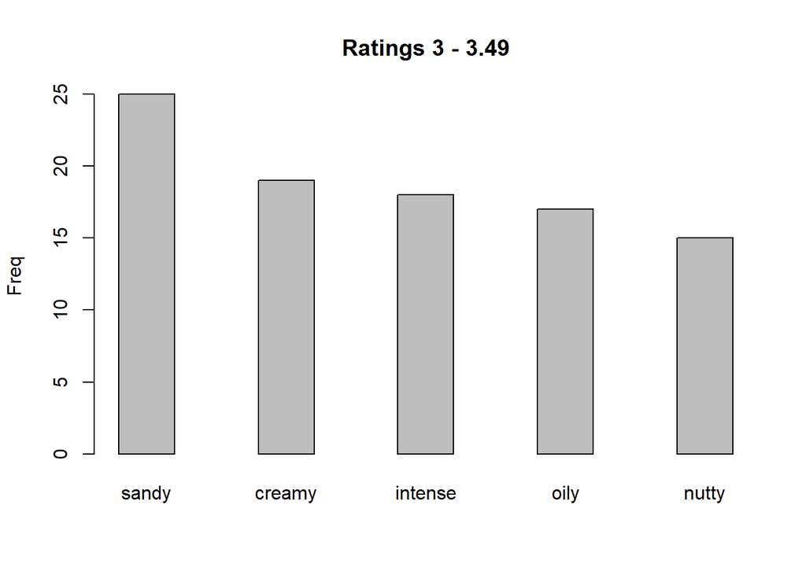

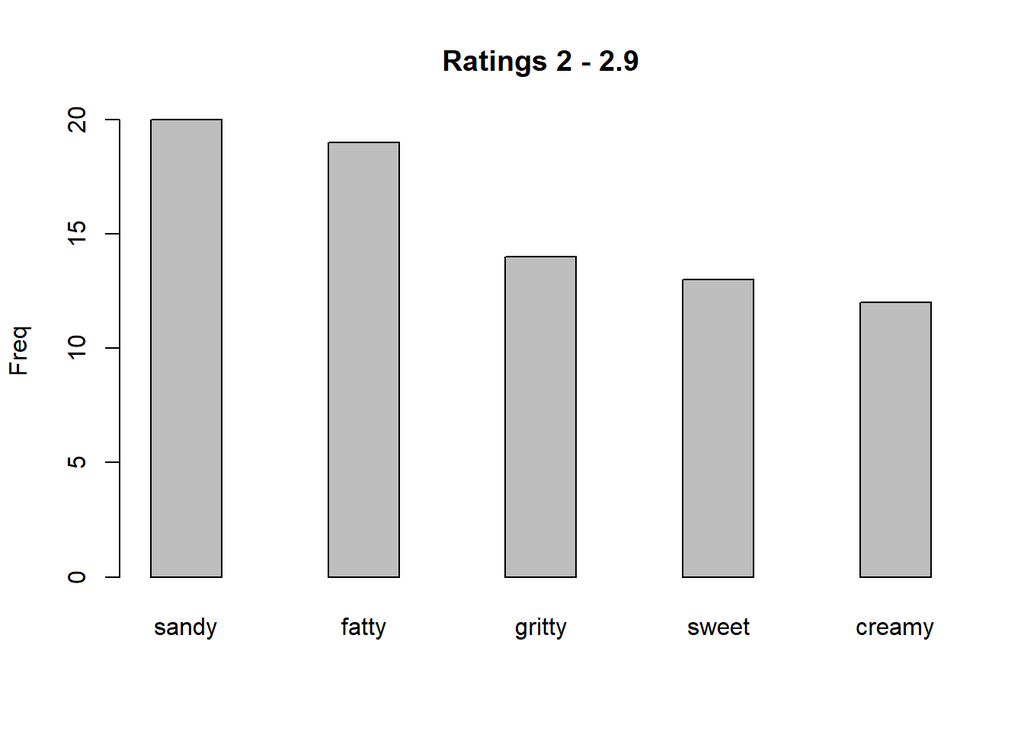

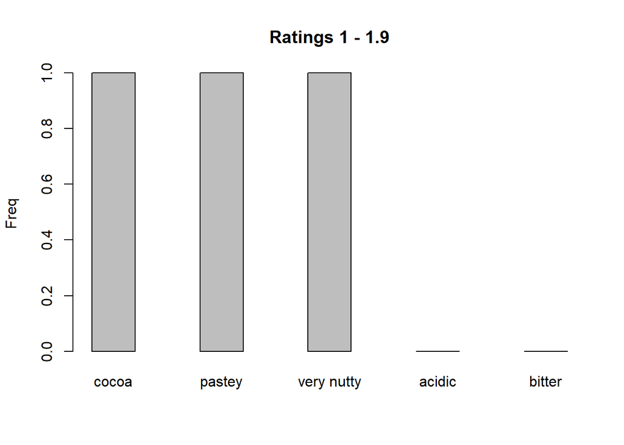

## 5

**Bean origin on rating**

I separated the ratings just like in #4

Venezuela is the most common in the 4 - 5 rating

Dominican Republic is most common in the 3 - 3.49 rating

Peru is most common in the 2 - 2.9 rating

```
##    choco.Bean_Origin choco.Rating Freq
## 23         Venezuela            4   18
## 17              Peru            4   16
## 13        Madagascar            4   10
## 7            Ecuador            4    8
## 2              Blend            4    7
```

```
##     choco.Bean_Origin choco.Rating Freq
## 53 Dominican Republic         3.75   36
## 85          Venezuela         3.75   36
## 70               Peru         3.75   26
## 54            Ecuador         3.75   24
## 64         Madagascar         3.75   19
```

```
##      choco.Bean_Origin choco.Rating Freq
## 73  Dominican Republic         3.25   42
## 75             Ecuador         3.25   37
## 96                Peru         3.25   30
## 117          Venezuela         3.25   29
## 63               Blend         3.25   21
```

```
##      choco.Bean_Origin choco.Rating Freq
## 236               Peru         2.75   30
## 254          Venezuela         2.75   29
## 214 Dominican Republic         2.75   28
## 215            Ecuador         2.75   24
## 228         Madagascar         2.75   23
```

```
##    choco.Bean_Origin choco.Rating Freq
## 16            Brazil         1.75    1
## 20         St. Lucia         1.75    1
## 21         Venezuela         1.75    1
## 15             Blend         1.75    0
## 17           Ecuador         1.75    0
```

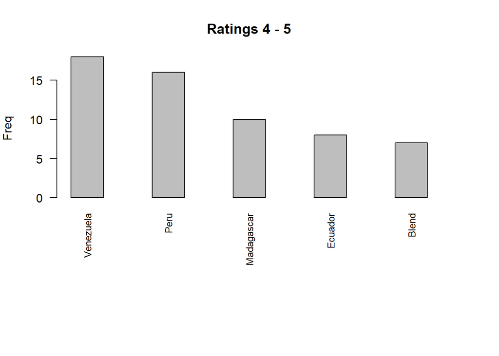

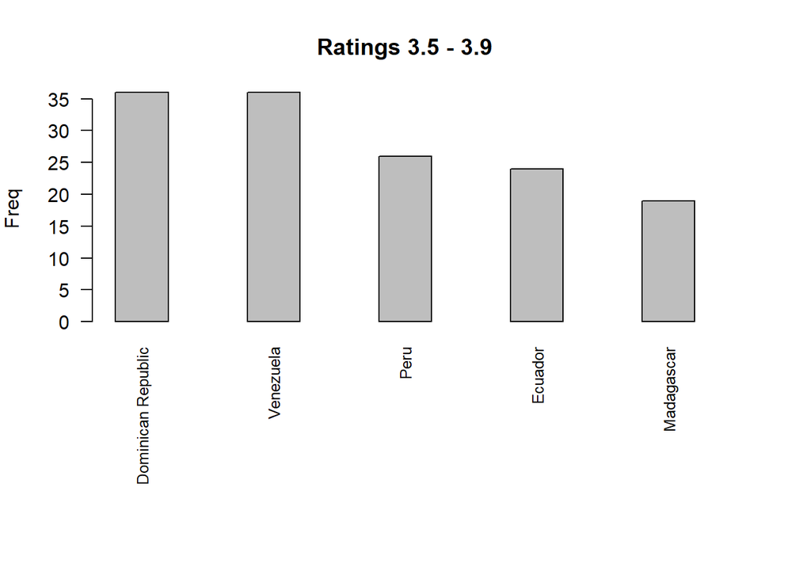

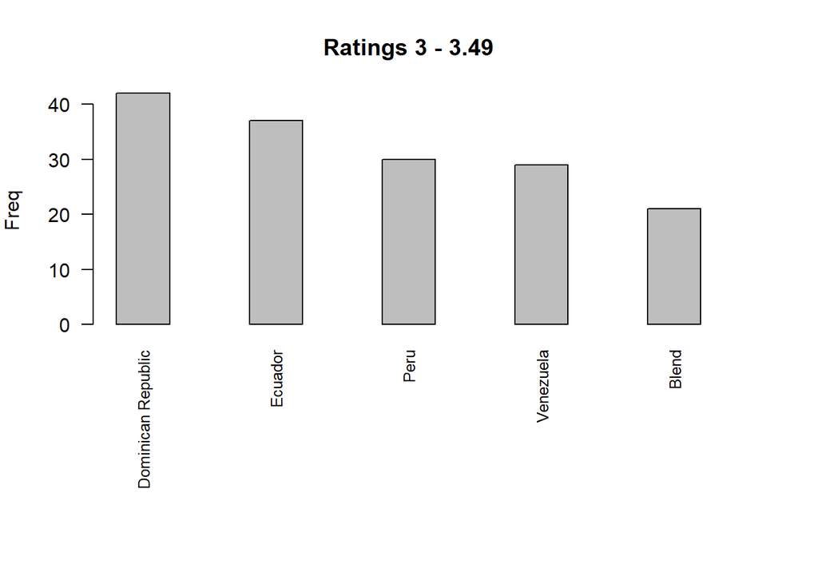

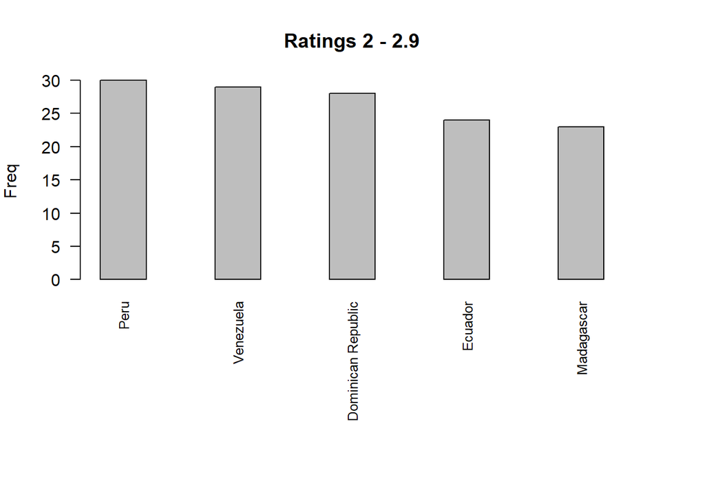

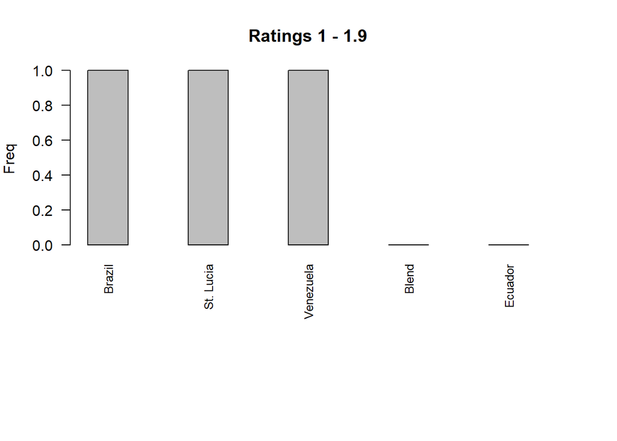

**Company on rating**

I separated the ratings just like in #4

Soma is the most common in the 4 - 5 rating

Soma is most common in the 3.5 - 4 rating

Soma is most common in the 3 - 3.49 rating

The most popular rated chocolate is made by Soma

But Soma also makes some mediocre chocolate as well

```
##    choco.Company choco.Rating Freq
## 42          Soma            4   13
## 9         Bonnat            4    8
## 4          Arete            4    6
## 16        Domori            4    4
## 20        Fresco            4    4
```

```
##              choco.Company choco.Rating Freq
## 528                   Soma         3.75   13
## 512                  Rogue         3.75    6
## 525 Smooth Chocolator, The         3.75    6
## 281               A. Morin         3.75    5
## 294                  Arete         3.75    5
```

```
##           choco.Company choco.Rating Freq
## 698                Soma         3.25    8
## 711        Szanto Tibor         3.25    7
## 398               Arete         3.25    6
## 527              Fresco         3.25    6
## 529 Friis Holm (Bonnat)         3.25    6
```

```
##                   choco.Company choco.Rating Freq
## 1330 Hotel Chocolat (Coppeneur)         2.75    5
## 1359                      Madre         2.75    5
## 1408            Palette de Bine         2.75    5
## 1189                   A. Morin         2.75    4
## 1211                    Beehive         2.75    4
```

```
##              choco.Company choco.Rating Freq
## 33     Artisan du Chocolat         1.75    2
## 42          Hotel Chocolat         1.75    1
## 34                  Bonnat         1.75    0
## 35  Bouga Cacao (Tulicorp)         1.75    0
## 36 Cacaoyere (Ecuatoriana)         1.75    0
```

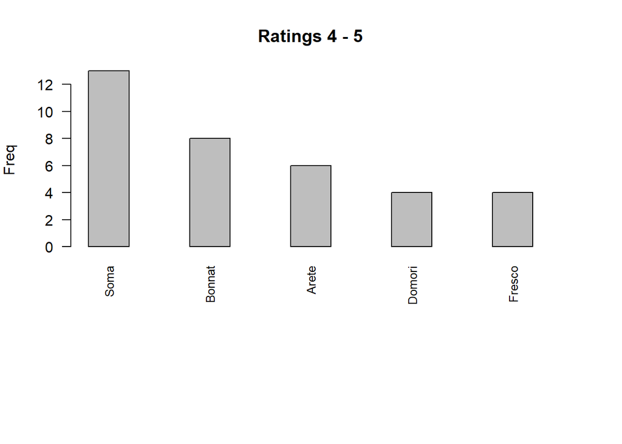

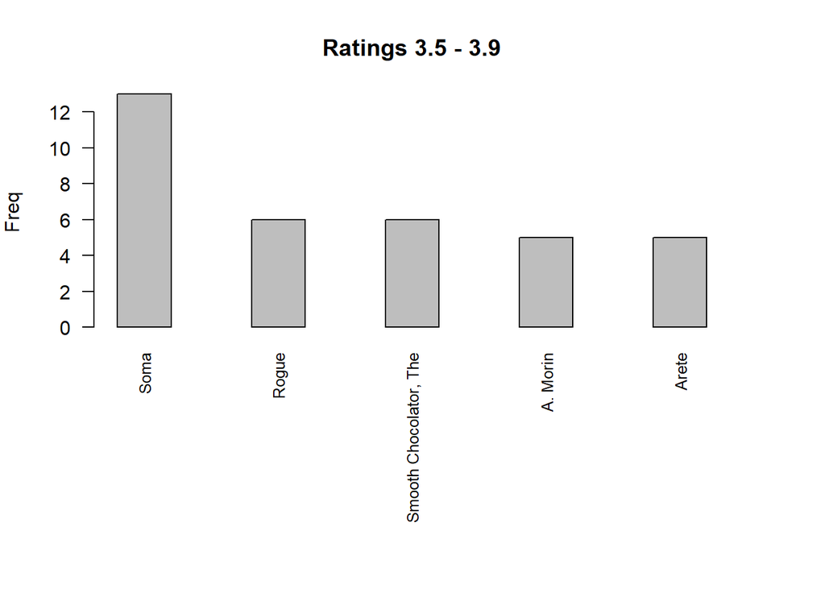

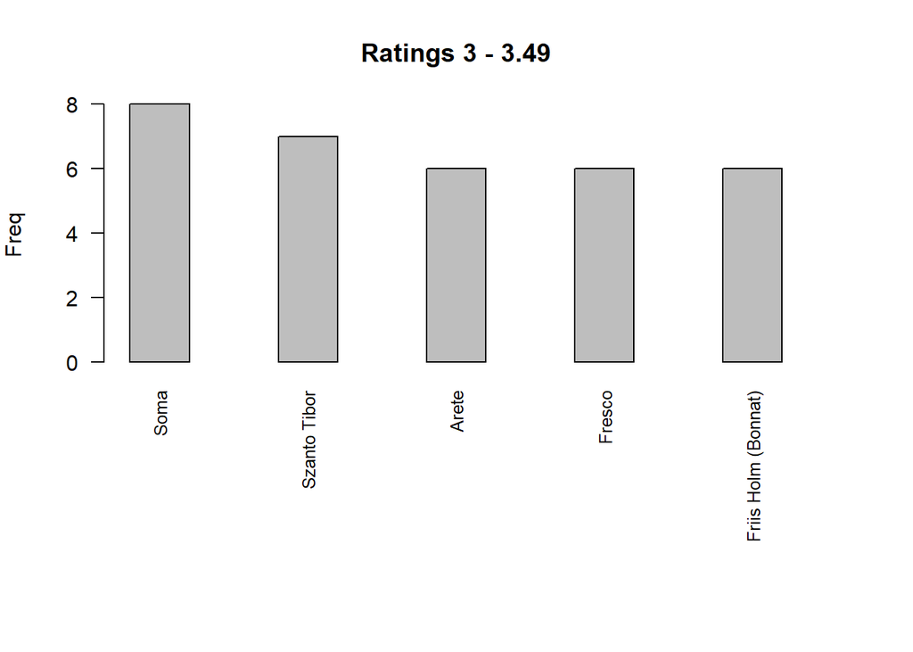

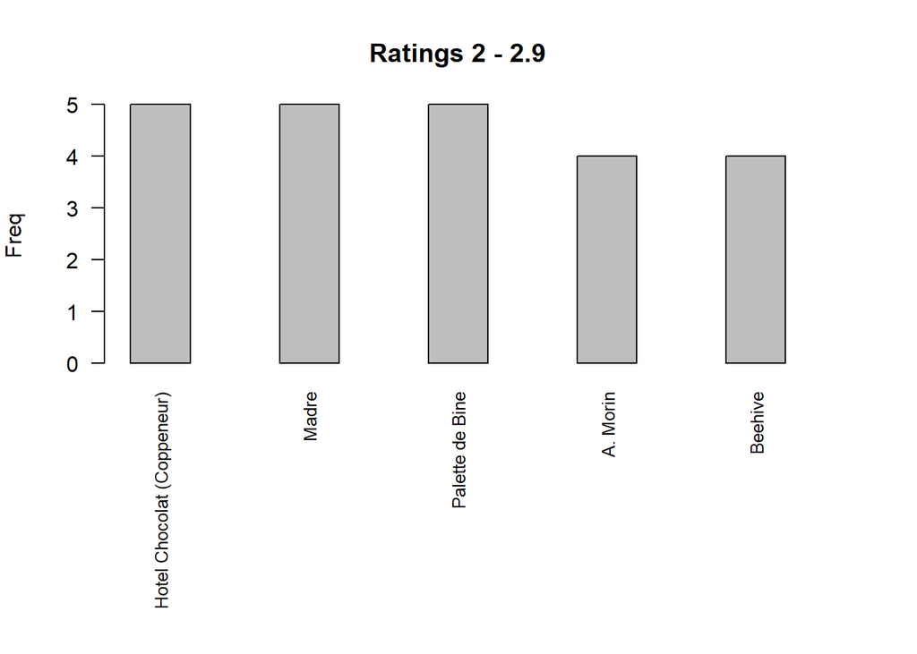

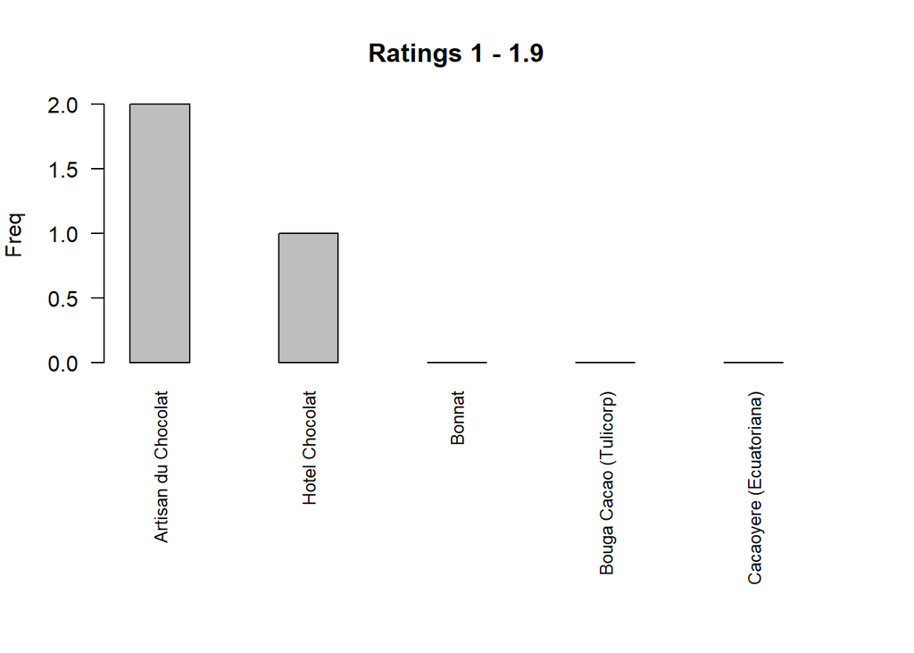